# INN_Learner_Notebook_Full_code

**Model_2:**

- Hidden layers = 2
- Activation function for hidden layers = Relu
- Output layer with 1 nodes
- Outout Activation function = Sigmoid
- Output loss function = Cross Entropy (since this is a classification problem)
- Optimizer = Adam
- epochs = 20
- Data is scaled using zscore
- Training the model on the oversampled train data set (using SMOTE)

```python
backend.clear_session()
#Fixing the seed for random number generators so that we can ensure we receive the same output everytime
np.random.seed(1)
random.seed(1)
tf.random.set_seed(1)
```

```python
# Initializing the model
model_02 = Sequential()
# Adding the first hidden layer with 64 neurons, relu as activation function
model_02.add(Dense(64, activation='relu', input_dim=11))
# Adding the second hidden layer with 32 neurons, relu as activation function
model_02.add(Dense(32, activation='relu'))
# Adding the output layer with one neuron and Sigmoid as activation
model_02.add(Dense(1, activation='sigmoid'))
```

```
319/319 ━━━━━━━━━━━━━━━━━━━━ 2s 3ms/step - accuracy: 0.6791 - loss: 0.5837 - val_accuracy: 0.6327 - val_loss: 0.6825
319/319 ━━━━━━━━━━━━━━━━━━━━ 1s 2ms/step - accuracy: 0.7892 - loss: 0.4460 - val_accuracy: 0.6601 - val_loss: 0.6462
319/319 ━━━━━━━━━━━━━━━━━━━━ 1s 2ms/step - accuracy: 0.8021 - loss: 0.4271 - val_accuracy: 0.6644 - val_loss: 0.6352
319/319 ━━━━━━━━━━━━━━━━━━━━ 1s 2ms/step - accuracy: 0.8050 - loss: 0.4194 - val_accuracy: 0.6719 - val_loss: 0.6281
319/319 ━━━━━━━━━━━━━━━━━━━━ 2s 3ms/step - accuracy: 0.8087 - loss: 0.4137 - val_accuracy: 0.6746 - val_loss: 0.6232
319/319 ━━━━━━━━━━━━━━━━━━━━ 1s 3ms/step - accuracy: 0.8111 - loss: 0.4088 - val_accuracy: 0.6762 - val_loss: 0.6172
319/319 ━━━━━━━━━━━━━━━━━━━━ 1s 3ms/step - accuracy: 0.8141 - loss: 0.4044 - val_accuracy: 0.6774 - val_loss: 0.6143
319/319 ━━━━━━━━━━━━━━━━━━━━ 1s 4ms/step - accuracy: 0.8174 - loss: 0.4001 - val_accuracy: 0.6786 - val_loss: 0.6094
319/319 ━━━━━━━━━━━━━━━━━━━━ 1s 2ms/step - accuracy: 0.8192 - loss: 0.3964 - val_accuracy: 0.6821 - val_loss: 0.6051
319/319 ━━━━━━━━━━━━━━━━━━━━ 1s 2ms/step - accuracy: 0.8194 - loss: 0.3929 - val_accuracy: 0.6864 - val_loss: 0.5976
319/319 ━━━━━━━━━━━━━━━━━━━━ 1s 2ms/step - accuracy: 0.8222 - loss: 0.3897 - val_accuracy: 0.6911 - val_loss: 0.5926
319/319 ━━━━━━━━━━━━━━━━━━━━ 1s 2ms/step - accuracy: 0.8224 - loss: 0.3865 - val_accuracy: 0.6919 - val_loss: 0.5905
319/319 ━━━━━━━━━━━━━━━━━━━━ 1s 2ms/step - accuracy: 0.8239 - loss: 0.3834 - val_accuracy: 0.6943 - val_loss: 0.5833
319/319 ━━━━━━━━━━━━━━━━━━━━ 1s 2ms/step - accuracy: 0.8252 - loss: 0.3805 - val_accuracy: 0.6970 - val_loss: 0.5784
319/319 ━━━━━━━━━━━━━━━━━━━━ 1s 2ms/step - accuracy: 0.8289 - loss: 0.3777 - val_accuracy: 0.6998 - val_loss: 0.5743
319/319 ━━━━━━━━━━━━━━━━━━━━ 1s 2ms/step - accuracy: 0.8296 - loss: 0.3751 - val_accuracy: 0.7029 - val_loss: 0.5690
319/319 ━━━━━━━━━━━━━━━━━━━━ 1s 2ms/step - accuracy: 0.8312 - loss: 0.3726 - val_accuracy: 0.7068 - val_loss: 0.5650
319/319 ━━━━━━━━━━━━━━━━━━━━ 1s 2ms/step - accuracy: 0.8325 - loss: 0.3701 - val_accuracy: 0.7072 - val_loss: 0.5606
319/319 ━━━━━━━━━━━━━━━━━━━━ 2s 3ms/step - accuracy: 0.8359 - loss: 0.3675 - val_accuracy: 0.7104 - val_loss: 0.5541
319/319 ━━━━━━━━━━━━━━━━━━━━ 1s 3ms/step - accuracy: 0.8358 - loss: 0.3650 - val_accuracy: 0.7108 - val_loss: 0.5507
```

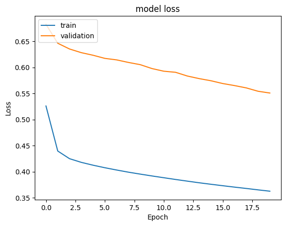

```python
# Compiling the model with 'cross entropy' as loss function, 'Adam' Optimizer and 'accuracy' metrics
model_02.compile(loss='binary_crossentropy',
              optimizer='Adam',
              metrics=['accuracy'])

# Fitting the model on train and validation with 20 epochs
fitted_model_02 = model_02.fit(X_train_over, y_train_over, validation_split=0.2,epochs=20)

#Plotting Train Loss vs Validation Loss
plt.plot(fitted_model_02.history['loss'])
plt.plot(fitted_model_02.history['val_loss'])
plt.title('model loss')
plt.ylabel('Loss')
plt.xlabel('Epoch')
plt.legend(['train', 'validation'], loc='upper left')
plt.show()
```

```
63/63 ━━━━━━━━━━━━━━━━━━━━ 0s 2ms/step
              precision    recall  f1-score   support

           0       0.89      0.89      0.89      1593
           1       0.58      0.59      0.58       407

    accuracy                           0.83      2000
   macro avg       0.74      0.74      0.74      2000
weighted avg       0.83      0.83      0.83      2000
```

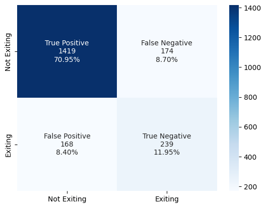

```python
# Obtain the y_predict from the X_test
y_pred=model_02.predict(X_test)

#set the threshold to 0.5
y_pred = (y_pred > 0.5)

# Display the classification report
cr=metrics.classification_report(y_test,y_pred)
print(cr)

#Calculating the confusion matrix
from sklearn.metrics import confusion_matrix
cm=confusion_matrix(y_test, y_pred)
labels = ['True Positive','False Negative','False Positive','True Negative']
categories = [ 'Not Exiting','Exiting']
make_confusion_matrix(cm,
                      group_names=labels,
                      categories=categories,
                      cmap='Blues')
```

**Observation:**

**Notes:**

- A trial was conducted using the undersampled training data on model_02 parameters, yet it resulted in lower Recall of 0.70, hence it was not included in this notebook.
- A trial was conducted using 50 ephochs on the over sampled training data and same model_02 parameters, yet it resulted in lower Recall of 0.73, hence it was not included in this notebook.

**Model_03:**  
In this model we will use the basic training data (not oversampled) and change only the optimize to SGD instead of Adam

- Hidden layers = 2
- Activation function for hidden layers = Relu
- Output layer with 1 nodes
- Outout Activation function = Sigmoid
- Output loss function = Cross Entropy (since this is a classification problem)
- Optimizer = SGD
- epochs = 20
- Data is scaled using zscore

**Build a model with Adam optimizer and Dropout**

```python
backend.clear_session()
#Fixing the seed for random number generators so that we can ensure we receive the same output everytime
np.random.seed(1)
random.seed(1)
tf.random.set_seed(1)
```

```python
from tensorflow.keras.models import Sequential
from tensorflow.keras.layers import Dense, Dropout
from tensorflow.keras.optimizers import Adam

# Define the model architecture
model = Sequential()

# Input layer with 64 neurons and ReLU activation function
model.add(Dense(64, activation='relu', input_dim=11))  # Adjust input_dim to the number of features in your data

# Dropout layer with 20% dropout rate
model.add(Dropout(0.2))

# Hidden layer with 32 neurons and ReLU activation function
model.add(Dense(32, activation='relu'))

# Dropout layer with 20% dropout rate
model.add(Dropout(0.2))

# Output layer with 1 neuron and sigmoid activation (suitable for binary classification)
model.add(Dense(1, activation='sigmoid'))

# Compile the model with the Adam optimizer
model.compile(optimizer=Adam(learning_rate=0.001),  # You can adjust the learning rate if needed
              loss='binary_crossentropy',           # Suitable for binary classification
              metrics=['accuracy'])                 # Track accuracy as a metric

# Display the model summary
model.summary()
```

```
Model: "sequential"
```

```
┏━━━━━━━━━━━━━━━━━━━━━━━━━━━━━━━━━━━━━━┳━━━━━━━━━━━━━━━━━━━━━━━━━━━━━┳━━━━━━━━━━━━━━━━━┓
┃ Layer (type)                         ┃ Output Shape                ┃         Param # ┃
┡━━━━━━━━━━━━━━━━━━━━━━━━━━━━━━━━━━━━━━╇━━━━━━━━━━━━━━━━━━━━━━━━━━━━━╇━━━━━━━━━━━━━━━━━┩
│ dense (Dense)                        │ (None, 64)                  │             768 │
├──────────────────────────────────────┼─────────────────────────────┼─────────────────┤
│ dropout (Dropout)                    │ (None, 64)                  │               0 │
├──────────────────────────────────────┼─────────────────────────────┼─────────────────┤
│ dense_1 (Dense)                      │ (None, 32)                  │           2,080 │
├──────────────────────────────────────┼─────────────────────────────┼─────────────────┤
│ dropout_1 (Dropout)                  │ (None, 32)                  │               0 │
├──────────────────────────────────────┼─────────────────────────────┼─────────────────┤
│ dense_2 (Dense)                      │ (None, 1)                   │              33 │
└──────────────────────────────────────┴─────────────────────────────┴─────────────────┘
```

```
 Total params: 2,881 (11.25 KB)
```

```
 Trainable params: 2,881 (11.25 KB)
```

```
 Non-trainable params: 0 (0.00 B)
```

```python
from imblearn.over_sampling import SMOTE

# Initialize SMOTE
smote = SMOTE(random_state=42)

# Fit and resample the training data
X_train_over, y_train_over = smote.fit_resample(X_train, y_train)
```

```python
backend.clear_session()
#Fixing the seed for random number generators so that we can ensure we receive the same output everytime
np.random.seed(1)
random.seed(1)
tf.random.set_seed(1)
```

```python
# Initializing the model
model_03 = Sequential()
# Adding the first hidden layer with 64 neurons, relu as activation function
model_03.add(Dense(64, activation='relu', input_dim=11))
# Adding the second hidden layer with 32 neurons, relu as activation function
model_03.add(Dense(32, activation='relu'))
# Adding the output layer with one neuron and Sigmoid as activation
model_03.add(Dense(1, activation='sigmoid'))
```

```python
# Compiling the model with 'cross entropy' as loss function, 'Adam' Optimizer and 'accuracy' metrics
model_03.compile(loss='binary_crossentropy',
              optimizer='SGD',
              metrics=['accuracy'])


# Fitting the model on train and validation with 20 epochs
fitted_model_03 = model_03.fit(X_train, y_train, validation_split=0.2,epochs=20)
```

```
200/200 ━━━━━━━━━━━━━━━━━━━━ 1s 3ms/step - accuracy: 0.6412 - loss: 0.6248 - val_accuracy: 0.7906 - val_loss: 0.4899
200/200 ━━━━━━━━━━━━━━━━━━━━ 0s 2ms/step - accuracy: 0.7929 - loss: 0.4810 - val_accuracy: 0.7906 - val_loss: 0.4630
200/200 ━━━━━━━━━━━━━━━━━━━━ 1s 2ms/step - accuracy: 0.7928 - loss: 0.4565 - val_accuracy: 0.7944 - val_loss: 0.4474
200/200 ━━━━━━━━━━━━━━━━━━━━ 0s 2ms/step - accuracy: 0.7968 - loss: 0.4410 - val_accuracy: 0.7975 - val_loss: 0.4363
200/200 ━━━━━━━━━━━━━━━━━━━━ 0s 2ms/step - accuracy: 0.8048 - loss: 0.4299 - val_accuracy: 0.8112 - val_loss: 0.4276
200/200 ━━━━━━━━━━━━━━━━━━━━ 1s 4ms/step - accuracy: 0.8095 - loss: 0.4214 - val_accuracy: 0.8169 - val_loss: 0.4201
200/200 ━━━━━━━━━━━━━━━━━━━━ 1s 5ms/step - accuracy: 0.8152 - loss: 0.4140 - val_accuracy: 0.8213 - val_loss: 0.4130
200/200 ━━━━━━━━━━━━━━━━━━━━ 1s 5ms/step - accuracy: 0.8212 - loss: 0.4073 - val_accuracy: 0.8269 - val_loss: 0.4063
200/200 ━━━━━━━━━━━━━━━━━━━━ 1s 3ms/step - accuracy: 0.8253 - loss: 0.4009 - val_accuracy: 0.8331 - val_loss: 0.4000
200/200 ━━━━━━━━━━━━━━━━━━━━ 1s 3ms/step - accuracy: 0.8309 - loss: 0.3948 - val_accuracy: 0.8388 - val_loss: 0.3937
200/200 ━━━━━━━━━━━━━━━━━━━━ 2s 7ms/step - accuracy: 0.8364 - loss: 0.3890 - val_accuracy: 0.8419 - val_loss: 0.3877
200/200 ━━━━━━━━━━━━━━━━━━━━ 2s 4ms/step - accuracy: 0.8420 - loss: 0.3834 - val_accuracy: 0.8481 - val_loss: 0.3819
200/200 ━━━━━━━━━━━━━━━━━━━━ 1s 5ms/step - accuracy: 0.8445 - loss: 0.3782 - val_accuracy: 0.8512 - val_loss: 0.3764
200/200 ━━━━━━━━━━━━━━━━━━━━ 1s 4ms/step - accuracy: 0.8458 - loss: 0.3735 - val_accuracy: 0.8525 - val_loss: 0.3716
200/200 ━━━━━━━━━━━━━━━━━━━━ 1s 3ms/step - accuracy: 0.8495 - loss: 0.3692 - val_accuracy: 0.8531 - val_loss: 0.3673
200/200 ━━━━━━━━━━━━━━━━━━━━ 2s 5ms/step - accuracy: 0.8513 - loss: 0.3655 - val_accuracy: 0.8575 - val_loss: 0.3636
200/200 ━━━━━━━━━━━━━━━━━━━━ 1s 2ms/step - accuracy: 0.8550 - loss: 0.3622 - val_accuracy: 0.8562 - val_loss: 0.3604
200/200 ━━━━━━━━━━━━━━━━━━━━ 1s 2ms/step - accuracy: 0.8561 - loss: 0.3594 - val_accuracy: 0.8587 - val_loss: 0.3577
200/200 ━━━━━━━━━━━━━━━━━━━━ 1s 2ms/step - accuracy: 0.8557 - loss: 0.3569 - val_accuracy: 0.8612 - val_loss: 0.3554
200/200 ━━━━━━━━━━━━━━━━━━━━ 1s 2ms/step - accuracy: 0.8570 - loss: 0.3548 - val_accuracy: 0.8625 - val_loss: 0.3536
```

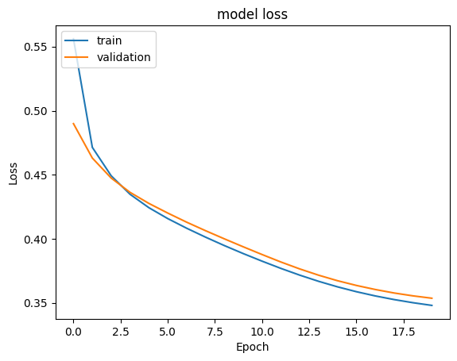

```python
#Plotting Train Loss vs Validation Loss
plt.plot(fitted_model_03.history['loss'])
plt.plot(fitted_model_03.history['val_loss'])
plt.title('model loss')
plt.ylabel('Loss')
plt.xlabel('Epoch')
plt.legend(['train', 'validation'], loc='upper left')
plt.show()
```

The error loss in validation and train sets is very close and much smoother (less noise). Let us explore how the performance metrics vary

```python
# Obtain the y_predict from the X_test
y_pred=model_03.predict(X_test)

#set the threshold to 0.5
y_pred = (y_pred > 0.5)

# Display the classification report
cr=metrics.classification_report(y_test,y_pred)
print(cr)
```

```
63/63 ━━━━━━━━━━━━━━━━━━━━ 0s 2ms/step
              precision    recall  f1-score   support

           0       0.87      0.96      0.91      1593
           1       0.74      0.43      0.54       407

    accuracy                           0.85      2000
   macro avg       0.81      0.70      0.73      2000
weighted avg       0.84      0.85      0.84      2000
```

The recall has actually decreased when compared to the previous models. Let us display the confusion matrix and observe how the FN count changed.

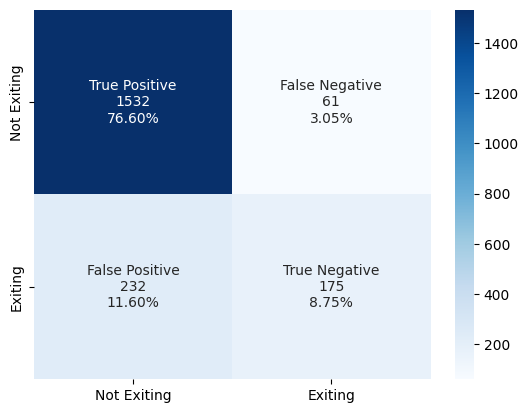

```python
#Calculating the confusion matrix
from sklearn.metrics import confusion_matrix
cm=confusion_matrix(y_test, y_pred)
labels = ['True Positive','False Negative','False Positive','True Negative']
categories = [ 'Not Exiting','Exiting']
make_confusion_matrix(cm,
                      group_names=labels,
                      categories=categories,
                      cmap='Blues')
```

The FN count has decreased yet the target variable imbalance is still affecting the figures. Let us train the same model on the oversampled data and observe the difference.

**Model_04:**  
In this model we will use the oversampled train data and keep the optimizer as SGD instead of Adam

- Hidden layers = 2
- Activation function for hidden layers = Relu
- Output layer with 1 nodes
- Outout Activation function = Sigmoid
- Output loss function = Cross Entropy (since this is a classification problem)
- Optimizer = SGD
- epochs = 20
- Data is scaled using zscore

```python
backend.clear_session()
#Fixing the seed for random number generators so that we can ensure we receive the same output everytime
np.random.seed(1)
import random
random.seed(1)
tf.random.set_seed(1)
```

```
319/319 ━━━━━━━━━━━━━━━━━━━━ 1s 2ms/step - accuracy: 0.5642 - loss: 0.6750 - val_accuracy: 0.2308 - val_loss: 0.8622
319/319 ━━━━━━━━━━━━━━━━━━━━ 1s 2ms/step - accuracy: 0.7117 - loss: 0.5801 - val_accuracy: 0.4600 - val_loss: 0.7952
319/319 ━━━━━━━━━━━━━━━━━━━━ 1s 2ms/step - accuracy: 0.7412 - loss: 0.5378 - val_accuracy: 0.5530 - val_loss: 0.7459
319/319 ━━━━━━━━━━━━━━━━━━━━ 1s 2ms/step - accuracy: 0.7560 - loss: 0.5115 - val_accuracy: 0.5911 - val_loss: 0.7129
319/319 ━━━━━━━━━━━━━━━━━━━━ 1s 3ms/step - accuracy: 0.7641 - loss: 0.4919 - val_accuracy: 0.6177 - val_loss: 0.6883
319/319 ━━━━━━━━━━━━━━━━━━━━ 1s 3ms/step - accuracy: 0.7787 - loss: 0.4754 - val_accuracy: 0.6248 - val_loss: 0.6687
319/319 ━━━━━━━━━━━━━━━━━━━━ 1s 3ms/step - accuracy: 0.7861 - loss: 0.4616 - val_accuracy: 0.6358 - val_loss: 0.6542
319/319 ━━━━━━━━━━━━━━━━━━━━ 1s 3ms/step - accuracy: 0.7926 - loss: 0.4507 - val_accuracy: 0.6511 - val_loss: 0.6433
319/319 ━━━━━━━━━━━━━━━━━━━━ 1s 2ms/step - accuracy: 0.7960 - loss: 0.4428 - val_accuracy: 0.6586 - val_loss: 0.6360
319/319 ━━━━━━━━━━━━━━━━━━━━ 1s 2ms/step - accuracy: 0.7973 - loss: 0.4371 - val_accuracy: 0.6644 - val_loss: 0.6317
319/319 ━━━━━━━━━━━━━━━━━━━━ 1s 2ms/step - accuracy: 0.8000 - loss: 0.4328 - val_accuracy: 0.6676 - val_loss: 0.6285
319/319 ━━━━━━━━━━━━━━━━━━━━ 1s 2ms/step - accuracy: 0.8019 - loss: 0.4295 - val_accuracy: 0.6711 - val_loss: 0.6261
319/319 ━━━━━━━━━━━━━━━━━━━━ 1s 2ms/step - accuracy: 0.8029 - loss: 0.4268 - val_accuracy: 0.6735 - val_loss: 0.6241
319/319 ━━━━━━━━━━━━━━━━━━━━ 1s 2ms/step - accuracy: 0.8035 - loss: 0.4245 - val_accuracy: 0.6762 - val_loss: 0.6221
319/319 ━━━━━━━━━━━━━━━━━━━━ 1s 2ms/step - accuracy: 0.8050 - loss: 0.4225 - val_accuracy: 0.6782 - val_loss: 0.6202
319/319 ━━━━━━━━━━━━━━━━━━━━ 1s 2ms/step - accuracy: 0.8055 - loss: 0.4208 - val_accuracy: 0.6801 - val_loss: 0.6192
319/319 ━━━━━━━━━━━━━━━━━━━━ 1s 2ms/step - accuracy: 0.8062 - loss: 0.4191 - val_accuracy: 0.6801 - val_loss: 0.6175
319/319 ━━━━━━━━━━━━━━━━━━━━ 1s 2ms/step - accuracy: 0.8075 - loss: 0.4176 - val_accuracy: 0.6801 - val_loss: 0.6168
319/319 ━━━━━━━━━━━━━━━━━━━━ 1s 2ms/step - accuracy: 0.8088 - loss: 0.4161 - val_accuracy: 0.6809 - val_loss: 0.6154
319/319 ━━━━━━━━━━━━━━━━━━━━ 1s 2ms/step - accuracy: 0.8090 - loss: 0.4146 - val_accuracy: 0.6817 - val_loss: 0.6144
```

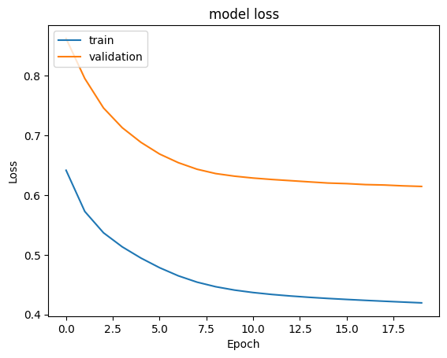

```python
# Initializing the model
model_04 = Sequential()
# Adding the first hidden layer with 64 neurons, relu as activation function
model_04.add(Dense(64, activation='relu', input_dim=11))
# Adding the second hidden layer with 32 neurons, relu as activation function
model_04.add(Dense(32, activation='relu'))
# Adding the output layer with one neuron and Sigmoid as activation
model_04.add(Dense(1, activation='sigmoid'))

# Compiling the model with 'cross entropy' as loss function, 'Adam' Optimizer and 'accuracy' metrics
model_04.compile(loss='binary_crossentropy',
              optimizer='SGD',
              metrics=['accuracy'])

# Fitting the model on train and validation with 20 epochs
fitted_model_04 = model_04.fit(X_train_over, y_train_over, validation_split=0.2,epochs=20)

#Plotting Train Loss vs Validation Loss
plt.plot(fitted_model_04.history['loss'])
plt.plot(fitted_model_04.history['val_loss'])
plt.title('model loss')
plt.ylabel('Loss')
plt.xlabel('Epoch')
plt.legend(['train', 'validation'], loc='upper left')
plt.show()
```

```python
# Obtain the y_predict from the X_test
y_pred=model_04.predict(X_test)

#set the threshold to 0.5
y_pred = (y_pred > 0.5)

# Display the classification report
cr=metrics.classification_report(y_test,y_pred)
print(cr)
```

```
63/63 ━━━━━━━━━━━━━━━━━━━━ 0s 2ms/step
              precision    recall  f1-score   support

           0       0.90      0.88      0.89      1593
           1       0.57      0.62      0.59       407

    accuracy                           0.83      2000
   macro avg       0.73      0.75      0.74      2000
weighted avg       0.83      0.83      0.83      2000
```

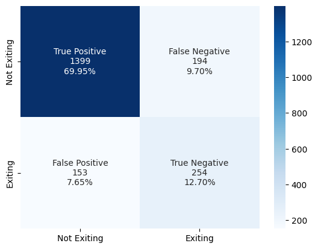

```python
#Calculating the confusion matrix
from sklearn.metrics import confusion_matrix
cm=confusion_matrix(y_test, y_pred)
labels = ['True Positive','False Negative','False Positive','True Negative']
categories = [ 'Not Exiting','Exiting']
make_confusion_matrix(cm,
                      group_names=labels,
                      categories=categories,
                      cmap='Blues')
```

The FN Count has increased significantly from 3% to 10%.

**Conclusion:**

Using over sampled data enhances the performance of the model, yet it adds in lots of noise and increases the overfitting and the FN count. The SGD Optimizer still shows less noise and less overfitting in the model, hence it is perferred over the Adam optimizer.

**Model_05:**  
In this model we will add 2 more hidden layer to have a total of 4 layers (160, 64, 32 and 16 Neurons respectively) and also add weight initialization using the he technique (since we are using the ReLU activation function).

- Hidden layers = 4
- Activation function for hidden layers = Relu
- Weight initialization technique = he
- Output layer with 1 nodes
- Output Activation function = Sigmoid
- Output loss function = Cross Entropy (since this is a classification problem)
- Optimizer = SGD
- epochs = 20
- Data is scaled using zscore

```python
backend.clear_session()
#Fixing the seed for random number generators so that we can ensure we receive the same output everytime
np.random.seed(1)
random.seed(1)
tf.random.set_seed(1)
```

```
319/319 ━━━━━━━━━━━━━━━━━━━━ 1s 3ms/step - accuracy: 0.6375 - loss: 0.6741 - val_accuracy: 0.5616 - val_loss: 0.7296
319/319 ━━━━━━━━━━━━━━━━━━━━ 1s 2ms/step - accuracy: 0.7559 - loss: 0.5064 - val_accuracy: 0.6444 - val_loss: 0.6546
319/319 ━━━━━━━━━━━━━━━━━━━━ 1s 2ms/step - accuracy: 0.7824 - loss: 0.4636 - val_accuracy: 0.6727 - val_loss: 0.6182
319/319 ━━━━━━━━━━━━━━━━━━━━ 1s 2ms/step - accuracy: 0.7968 - loss: 0.4364 - val_accuracy: 0.6876 - val_loss: 0.5919
319/319 ━━━━━━━━━━━━━━━━━━━━ 1s 2ms/step - accuracy: 0.8050 - loss: 0.4208 - val_accuracy: 0.6907 - val_loss: 0.5837
319/319 ━━━━━━━━━━━━━━━━━━━━ 1s 2ms/step - accuracy: 0.8107 - loss: 0.4103 - val_accuracy: 0.6970 - val_loss: 0.5759
319/319 ━━━━━━━━━━━━━━━━━━━━ 1s 2ms/step - accuracy: 0.8146 - loss: 0.4023 - val_accuracy: 0.7084 - val_loss: 0.5625
319/319 ━━━━━━━━━━━━━━━━━━━━ 1s 2ms/step - accuracy: 0.8179 - loss: 0.3953 - val_accuracy: 0.7233 - val_loss: 0.5447
319/319 ━━━━━━━━━━━━━━━━━━━━ 1s 3ms/step - accuracy: 0.8217 - loss: 0.3892 - val_accuracy: 0.7253 - val_loss: 0.5426
319/319 ━━━━━━━━━━━━━━━━━━━━ 1s 3ms/step - accuracy: 0.8257 - loss: 0.3835 - val_accuracy: 0.7288 - val_loss: 0.5353
319/319 ━━━━━━━━━━━━━━━━━━━━ 1s 3ms/step - accuracy: 0.8287 - loss: 0.3783 - val_accuracy: 0.7339 - val_loss: 0.5309
319/319 ━━━━━━━━━━━━━━━━━━━━ 1s 2ms/step - accuracy: 0.8334 - loss: 0.3732 - val_accuracy: 0.7374 - val_loss: 0.5226
319/319 ━━━━━━━━━━━━━━━━━━━━ 1s 2ms/step - accuracy: 0.8362 - loss: 0.3683 - val_accuracy: 0.7469 - val_loss: 0.5118
319/319 ━━━━━━━━━━━━━━━━━━━━ 1s 2ms/step - accuracy: 0.8376 - loss: 0.3639 - val_accuracy: 0.7488 - val_loss: 0.5119
319/319 ━━━━━━━━━━━━━━━━━━━━ 1s 2ms/step - accuracy: 0.8394 - loss: 0.3599 - val_accuracy: 0.7473 - val_loss: 0.5123
319/319 ━━━━━━━━━━━━━━━━━━━━ 1s 2ms/step - accuracy: 0.8420 - loss: 0.3561 - val_accuracy: 0.7531 - val_loss: 0.5085
319/319 ━━━━━━━━━━━━━━━━━━━━ 1s 2ms/step - accuracy: 0.8441 - loss: 0.3524 - val_accuracy: 0.7520 - val_loss: 0.5071
319/319 ━━━━━━━━━━━━━━━━━━━━ 1s 2ms/step - accuracy: 0.8471 - loss: 0.3487 - val_accuracy: 0.7567 - val_loss: 0.5051
319/319 ━━━━━━━━━━━━━━━━━━━━ 1s 2ms/step - accuracy: 0.8489 - loss: 0.3449 - val_accuracy: 0.7578 - val_loss: 0.5032
319/319 ━━━━━━━━━━━━━━━━━━━━ 1s 2ms/step - accuracy: 0.8512 - loss: 0.3414 - val_accuracy: 0.7610 - val_loss: 0.4992
```

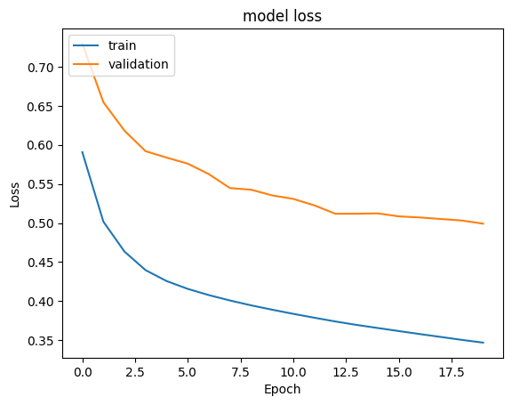

```python
# Initializing the model
model_05 = Sequential()
# Adding the first hidden layer, relu as activation function and, he_uniform as weight initializer.
model_05.add(Dense(160, activation='relu', input_dim=11, kernel_initializer='he_uniform'))
# Adding the second hidden layer , relu as activation function and, he_uniform as weight initializer
model_05.add(Dense(64, activation='relu', kernel_initializer='he_uniform'))
# Adding the third hidden layer , relu as activation function and, he_uniform as weight initializer
model_05.add(Dense(32, activation='relu', kernel_initializer='he_uniform'))
# Adding the fourth hidden layer , relu as activation function and, he_uniform as weight initializer
model_05.add(Dense(16, activation='relu', kernel_initializer='he_uniform'))

# Adding the output layer with one neuron and Sigmoid as activation
model_05.add(Dense(1, activation='sigmoid', kernel_initializer='he_uniform'))

# Compiling the model with 'cross entropy' as loss function, 'Adam' Optimizer and 'accuracy' metrics
model_05.compile(loss='binary_crossentropy',
              optimizer='SGD',
              metrics=['accuracy'])

# Fitting the model on train and validation with 20 epochs
fitted_model_05 = model_05.fit(X_train_over, y_train_over, validation_split=0.2,epochs=20)

#Plotting Train Loss vs Validation Loss
plt.plot(fitted_model_05.history['loss'])
plt.plot(fitted_model_05.history['val_loss'])
plt.title('model loss')
plt.ylabel('Loss')
plt.xlabel('Epoch')
plt.legend(['train', 'validation'], loc='upper left')
plt.show()
```

```
63/63 ━━━━━━━━━━━━━━━━━━━━ 0s 2ms/step
              precision    recall  f1-score   support

           0       0.90      0.88      0.89      1593
           1       0.56      0.60      0.58       407

    accuracy                           0.82      2000
   macro avg       0.73      0.74      0.73      2000
weighted avg       0.83      0.82      0.82      2000
```

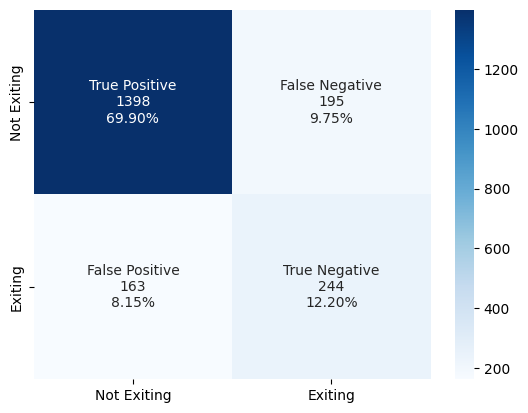

```python
# Obtain the y_predict from the X_test
y_pred=model_05.predict(X_test)

#set the threshold to 0.5
y_pred = (y_pred > 0.5)

# Display the classification report
cr=metrics.classification_report(y_test,y_pred)
print(cr)

#Calculating the confusion matrix
cm=confusion_matrix(y_test, y_pred)
labels = ['True Positive','False Negative','False Positive','True Negative']
categories = [ 'Not Exiting','Exiting']
make_confusion_matrix(cm,
                      group_names=labels,
                      categories=categories,
                      cmap='Blues')
```

**Observation:**

The recall has decreased while the FN Ratio has stayed almost the same. The weight initialization does not seem to add any value in enhancing the model performance.

**Model_06:**

In this model we will increase the number of epochs to 50 in order to decrease the error values, use the oversampled data and remove the weight initializer.

- Hidden layers = 4
- Activation function for hidden layers = Relu
- Output layer with 1 nodes
- Outout Activation function = Sigmoid
- Output loss function = Cross Entropy (since this is a classification problem)
- Optimizer = SGD
- epochs = 50
- Data is scaled using zscore

```python
backend.clear_session()
#Fixing the seed for random number generators so that we can ensure we receive the same output everytime
np.random.seed(1)
random.seed(1)
tf.random.set_seed(1)
```

```
319/319 ━━━━━━━━━━━━━━━━━━━━ 2s 3ms/step - accuracy: 0.5471 - loss: 0.6837 - val_accuracy: 0.2441 - val_loss: 0.8201
319/319 ━━━━━━━━━━━━━━━━━━━━ 1s 2ms/step - accuracy: 0.7021 - loss: 0.6041 - val_accuracy: 0.4513 - val_loss: 0.7655
319/319 ━━━━━━━━━━━━━━━━━━━━ 1s 2ms/step - accuracy: 0.7405 - loss: 0.5430 - val_accuracy: 0.5495 - val_loss: 0.7297
319/319 ━━━━━━━━━━━━━━━━━━━━ 1s 2ms/step - accuracy: 0.7632 - loss: 0.5044 - val_accuracy: 0.6024 - val_loss: 0.6904
319/319 ━━━━━━━━━━━━━━━━━━━━ 1s 2ms/step - accuracy: 0.7848 - loss: 0.4732 - val_accuracy: 0.6319 - val_loss: 0.6572
319/319 ━━━━━━━━━━━━━━━━━━━━ 1s 2ms/step - accuracy: 0.7978 - loss: 0.4474 - val_accuracy: 0.6570 - val_loss: 0.6302
319/319 ━━━━━━━━━━━━━━━━━━━━ 1s 2ms/step - accuracy: 0.8002 - loss: 0.4307 - val_accuracy: 0.6637 - val_loss: 0.6176
319/319 ━━━━━━━━━━━━━━━━━━━━ 1s 3ms/step - accuracy: 0.8040 - loss: 0.4207 - val_accuracy: 0.6727 - val_loss: 0.6060
319/319 ━━━━━━━━━━━━━━━━━━━━ 1s 3ms/step - accuracy: 0.8072 - loss: 0.4138 - val_accuracy: 0.6809 - val_loss: 0.5949
319/319 ━━━━━━━━━━━━━━━━━━━━ 1s 3ms/step - accuracy: 0.8102 - loss: 0.4084 - val_accuracy: 0.6868 - val_loss: 0.5888
319/319 ━━━━━━━━━━━━━━━━━━━━ 1s 4ms/step - accuracy: 0.8118 - loss: 0.4038 - val_accuracy: 0.6900 - val_loss: 0.5827
319/319 ━━━━━━━━━━━━━━━━━━━━ 1s 2ms/step - accuracy: 0.8150 - loss: 0.3997 - val_accuracy: 0.6962 - val_loss: 0.5778
319/319 ━━━━━━━━━━━━━━━━━━━━ 1s 2ms/step - accuracy: 0.8182 - loss: 0.3960 - val_accuracy: 0.6974 - val_loss: 0.5723
319/319 ━━━━━━━━━━━━━━━━━━━━ 1s 2ms/step - accuracy: 0.8201 - loss: 0.3926 - val_accuracy: 0.7002 - val_loss: 0.5676
319/319 ━━━━━━━━━━━━━━━━━━━━ 1s 3ms/step - accuracy: 0.8227 - loss: 0.3893 - val_accuracy: 0.7072 - val_loss: 0.5622
319/319 ━━━━━━━━━━━━━━━━━━━━ 1s 3ms/step - accuracy: 0.8243 - loss: 0.3862 - val_accuracy: 0.7131 - val_loss: 0.5537
319/319 ━━━━━━━━━━━━━━━━━━━━ 1s 3ms/step - accuracy: 0.8274 - loss: 0.3830 - val_accuracy: 0.7182 - val_loss: 0.5479
319/319 ━━━━━━━━━━━━━━━━━━━━ 1s 4ms/step - accuracy: 0.8295 - loss: 0.3799 - val_accuracy: 0.7221 - val_loss: 0.5422
319/319 ━━━━━━━━━━━━━━━━━━━━ 1s 3ms/step - accuracy: 0.8298 - loss: 0.3770 - val_accuracy: 0.7261 - val_loss: 0.5391
319/319 ━━━━━━━━━━━━━━━━━━━━ 1s 4ms/step - accuracy: 0.8312 - loss: 0.3741 - val_accuracy: 0.7296 - val_loss: 0.5347
319/319 ━━━━━━━━━━━━━━━━━━━━ 2s 5ms/step - accuracy: 0.8319 - loss: 0.3712 - val_accuracy: 0.7312 - val_loss: 0.5319
319/319 ━━━━━━━━━━━━━━━━━━━━ 2s 5ms/step - accuracy: 0.8342 - loss: 0.3683 - val_accuracy: 0.7351 - val_loss: 0.5256
319/319 ━━━━━━━━━━━━━━━━━━━━ 1s 4ms/step - accuracy: 0.8342 - loss: 0.3653 - val_accuracy: 0.7382 - val_loss: 0.5217
319/319 ━━━━━━━━━━━━━━━━━━━━ 1s 3ms/step - accuracy: 0.8363 - loss: 0.3626 - val_accuracy: 0.7402 - val_loss: 0.5179
319/319 ━━━━━━━━━━━━━━━━━━━━ 1s 3ms/step - accuracy: 0.8365 - loss: 0.3597 - val_accuracy: 0.7425 - val_loss: 0.5150
319/319 ━━━━━━━━━━━━━━━━━━━━ 1s 2ms/step - accuracy: 0.8401 - loss: 0.3566 - val_accuracy: 0.7449 - val_loss: 0.5128
319/319 ━━━━━━━━━━━━━━━━━━━━ 1s 2ms/step - accuracy: 0.8411 - loss: 0.3537 - val_accuracy: 0.7476 - val_loss: 0.5074
319/319 ━━━━━━━━━━━━━━━━━━━━ 1s 2ms/step - accuracy: 0.8401 - loss: 0.3505 - val_accuracy: 0.7531 - val_loss: 0.5037
319/319 ━━━━━━━━━━━━━━━━━━━━ 1s 2ms/step - accuracy: 0.8424 - loss: 0.3474 - val_accuracy: 0.7524 - val_loss: 0.5018
319/319 ━━━━━━━━━━━━━━━━━━━━ 1s 2ms/step - accuracy: 0.8436 - loss: 0.3442 - val_accuracy: 0.7567 - val_loss: 0.4953
319/319 ━━━━━━━━━━━━━━━━━━━━ 1s 2ms/step - accuracy: 0.8456 - loss: 0.3410 - val_accuracy: 0.7598 - val_loss: 0.4933
319/319 ━━━━━━━━━━━━━━━━━━━━ 1s 2ms/step - accuracy: 0.8475 - loss: 0.3378 - val_accuracy: 0.7614 - val_loss: 0.4915
319/319 ━━━━━━━━━━━━━━━━━━━━ 1s 2ms/step - accuracy: 0.8491 - loss: 0.3346 - val_accuracy: 0.7622 - val_loss: 0.4911
319/319 ━━━━━━━━━━━━━━━━━━━━ 1s 2ms/step - accuracy: 0.8504 - loss: 0.3316 - val_accuracy: 0.7618 - val_loss: 0.4902
319/319 ━━━━━━━━━━━━━━━━━━━━ 2s 3ms/step - accuracy: 0.8515 - loss: 0.3286 - val_accuracy: 0.7673 - val_loss: 0.4819
319/319 ━━━━━━━━━━━━━━━━━━━━ 1s 3ms/step - accuracy: 0.8527 - loss: 0.3257 - val_accuracy: 0.7633 - val_loss: 0.4860
319/319 ━━━━━━━━━━━━━━━━━━━━ 1s 4ms/step - accuracy: 0.8529 - loss: 0.3229 - val_accuracy: 0.7653 - val_loss: 0.4824
319/319 ━━━━━━━━━━━━━━━━━━━━ 1s 3ms/step - accuracy: 0.8550 - loss: 0.3200 - val_accuracy: 0.7716 - val_loss: 0.4723
319/319 ━━━━━━━━━━━━━━━━━━━━ 1s 2ms/step - accuracy: 0.8575 - loss: 0.3173 - val_accuracy: 0.7720 - val_loss: 0.4718
319/319 ━━━━━━━━━━━━━━━━━━━━ 1s 2ms/step - accuracy: 0.8585 - loss: 0.3145 - val_accuracy: 0.7802 - val_loss: 0.4661
319/319 ━━━━━━━━━━━━━━━━━━━━ 1s 2ms/step - accuracy: 0.8595 - loss: 0.3119 - val_accuracy: 0.7830 - val_loss: 0.4640
319/319 ━━━━━━━━━━━━━━━━━━━━ 1s 2ms/step - accuracy: 0.8610 - loss: 0.3094 - val_accuracy: 0.7838 - val_loss: 0.4584
319/319 ━━━━━━━━━━━━━━━━━━━━ 1s 2ms/step - accuracy: 0.8626 - loss: 0.3070 - val_accuracy: 0.7912 - val_loss: 0.4480
319/319 ━━━━━━━━━━━━━━━━━━━━ 1s 2ms/step - accuracy: 0.8620 - loss: 0.3044 - val_accuracy: 0.7998 - val_loss: 0.4355
319/319 ━━━━━━━━━━━━━━━━━━━━ 1s 2ms/step - accuracy: 0.8614 - loss: 0.3020 - val_accuracy: 0.8018 - val_loss: 0.4327
319/319 ━━━━━━━━━━━━━━━━━━━━ 1s 3ms/step - accuracy: 0.8624 - loss: 0.2995 - val_accuracy: 0.8042 - val_loss: 0.4271
319/319 ━━━━━━━━━━━━━━━━━━━━ 2s 5ms/step - accuracy: 0.8628 - loss: 0.2971 - val_accuracy: 0.8053 - val_loss: 0.4227
319/319 ━━━━━━━━━━━━━━━━━━━━ 3s 5ms/step - accuracy: 0.8650 - loss: 0.2947 - val_accuracy: 0.8053 - val_loss: 0.4209
319/319 ━━━━━━━━━━━━━━━━━━━━ 2s 5ms/step - accuracy: 0.8659 - loss: 0.2922 - val_accuracy: 0.8151 - val_loss: 0.4108
319/319 ━━━━━━━━━━━━━━━━━━━━ 1s 4ms/step - accuracy: 0.8684 - loss: 0.2899 - val_accuracy: 0.8246 - val_loss: 0.3988
```

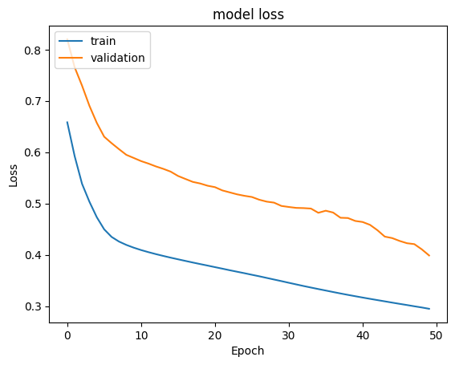

```python
# Initializing the model
model_06 = Sequential()
# Adding the first hidden layer, relu as activation function
model_06.add(Dense(160, activation='relu', input_dim=11))
# Adding the second hidden layer , relu as activation function
model_06.add(Dense(64, activation='relu'))
# Adding the third hidden layer , relu as activation function
model_06.add(Dense(32, activation='relu'))
# Adding the fourth hidden layer , relu as activation function
model_06.add(Dense(16, activation='relu'))
# Adding the output layer with one neuron and Sigmoid as activation
model_06.add(Dense(1, activation='sigmoid'))

# Compiling the model with 'cross entropy' as loss function, 'Adam' Optimizer and 'accuracy' metrics
model_06.compile(loss='binary_crossentropy',
              optimizer='SGD',
              metrics=['accuracy'])

# Fitting the model on train and validation with 20 epochs
fitted_model_06 = model_06.fit(X_train_over, y_train_over, validation_split=0.2,epochs=50)

#Plotting Train Loss vs Validation Loss
plt.plot(fitted_model_06.history['loss'])
plt.plot(fitted_model_06.history['val_loss'])
plt.title('model loss')
plt.ylabel('Loss')
plt.xlabel('Epoch')
plt.legend(['train', 'validation'], loc='upper left')
plt.show()
```

The error value has decreased and seem to stabilize a bit for the validation set as the epochs increase, yet the noise observed on the validation set is higher with higher epochs. It seems that 50 epochs is the right value to stop at, yet we need to reduce the noise and overfit, hence we will apply some regulaziation techniques. Let us observe the performance metrics first.

```python
# Obtain the y_predict from the X_test
y_pred=model_06.predict(X_test)

#set the threshold to 0.5
y_pred = (y_pred > 0.5)

# Display the classification report
cr=metrics.classification_report(y_test,y_pred)
print(cr)

#Calculating the confusion matrix
from sklearn.metrics import confusion_matrix
cm=confusion_matrix(y_test, y_pred)
labels = ['True Positive','False Negative','False Positive','True Negative']
categories = [ 'Not Exiting','Exiting']
make_confusion_matrix(cm,
                      group_names=labels,
                      categories=categories,
                      cmap='Blues')
```

[output not shown]

**Model_07:**  
In this model we will apply the Dropout Regularization technique while keeping all other hyperparameters and NN Structure fixed as in model_06

- Hidden layers = 4
- Activation function for hidden layers = Relu
- Output layer with 1 nodes
- Output Activation function = Sigmoid
- Output loss function = Cross Entropy (since this is a classification problem)
- Optimizer = SGD
- epochs = 50
- Data is scaled using zscore
- Regularization technique: DropOut

```python
backend.clear_session()
#Fixing the seed for random number generators so that we can ensure we receive the same output everytime
np.random.seed(1)
random.seed(1)
tf.random.set_seed(1)
```

```python
# Initializing the model
model_07 = Sequential()
# Adding the first hidden layer with 160 neurons, relu as activation function
model_07.add(Dense(160, activation='relu', input_dim=11))
# Adding dropout of 20%
model_07.add(Dropout(0.2))
# Adding the second hidden layer with 64 neurons, relu as activation function
model_07.add(Dense(64, activation='relu', input_dim=11))
# Adding dropout of 20%
model_07.add(Dropout(0.2))
# Adding the third hidden layer with 32 neurons, relu as activation function
model_07.add(Dense(32, activation='relu'))
# Adding dropout of 20%
model_07.add(Dropout(0.2))
# Adding the fourth hidden layer with 16 neurons, relu as activation function
model_07.add(Dense(16, activation='relu'))
# Adding dropout of 20%
model_07.add(Dropout(0.2))
# Adding the output layer with one neuron and Sigmoid as activation
model_07.add(Dense(1, activation='sigmoid'))
```

```python
# Display the Model summary to make sure all layers are well arranged
model_07.summary()
```

```
Model: "sequential"
```

```
┏━━━━━━━━━━━━━━━━━━━━━━━━━━━━━━━━━━━━━━┳━━━━━━━━━━━━━━━━━━━━━━━━━━━━━┳━━━━━━━━━━━━━━━━━┓
┃ Layer (type)                         ┃ Output Shape                ┃         Param # ┃
┡━━━━━━━━━━━━━━━━━━━━━━━━━━━━━━━━━━━━━━╇━━━━━━━━━━━━━━━━━━━━━━━━━━━━━╇━━━━━━━━━━━━━━━━━┩
│ dense (Dense)                        │ (None, 160)                 │           1,920 │
├──────────────────────────────────────┼─────────────────────────────┼─────────────────┤
│ dropout (Dropout)                    │ (None, 160)                 │               0 │
├──────────────────────────────────────┼─────────────────────────────┼─────────────────┤
│ dense_1 (Dense)                      │ (None, 64)                  │          10,304 │
├──────────────────────────────────────┼─────────────────────────────┼─────────────────┤
│ dropout_1 (Dropout)                  │ (None, 64)                  │               0 │
├──────────────────────────────────────┼─────────────────────────────┼─────────────────┤
│ dense_2 (Dense)                      │ (None, 32)                  │           2,080 │
├──────────────────────────────────────┼─────────────────────────────┼─────────────────┤
│ dropout_2 (Dropout)                  │ (None, 32)                  │               0 │
├──────────────────────────────────────┼─────────────────────────────┼─────────────────┤
│ dense_3 (Dense)                      │ (None, 16)                  │             528 │
├──────────────────────────────────────┼─────────────────────────────┼─────────────────┤
│ dropout_3 (Dropout)                  │ (None, 16)                  │               0 │
├──────────────────────────────────────┼─────────────────────────────┼─────────────────┤
│ dense_4 (Dense)                      │ (None, 1)                   │              17 │
└──────────────────────────────────────┴─────────────────────────────┴─────────────────┘
```

```
 Total params: 14,849 (58.00 KB)
```

```
 Trainable params: 14,849 (58.00 KB)
```

```
 Non-trainable params: 0 (0.00 B)
```

```
319/319 ━━━━━━━━━━━━━━━━━━━━ 2s 3ms/step - accuracy: 0.5977 - loss: 0.6726 - val_accuracy: 0.0024 - val_loss: 0.8926
319/319 ━━━━━━━━━━━━━━━━━━━━ 1s 2ms/step - accuracy: 0.6372 - loss: 0.6340 - val_accuracy: 0.2166 - val_loss: 0.8769
319/319 ━━━━━━━━━━━━━━━━━━━━ 1s 2ms/step - accuracy: 0.6783 - loss: 0.6017 - val_accuracy: 0.5090 - val_loss: 0.8119
319/319 ━━━━━━━━━━━━━━━━━━━━ 1s 2ms/step - accuracy: 0.7084 - loss: 0.5734 - val_accuracy: 0.6056 - val_loss: 0.7842
319/319 ━━━━━━━━━━━━━━━━━━━━ 1s 3ms/step - accuracy: 0.7217 - loss: 0.5499 - val_accuracy: 0.6597 - val_loss: 0.7530
319/319 ━━━━━━━━━━━━━━━━━━━━ 1s 2ms/step - accuracy: 0.7306 - loss: 0.5397 - val_accuracy: 0.6935 - val_loss: 0.7136
319/319 ━━━━━━━━━━━━━━━━━━━━ 1s 3ms/step - accuracy: 0.7445 - loss: 0.5282 - val_accuracy: 0.6829 - val_loss: 0.7159
319/319 ━━━━━━━━━━━━━━━━━━━━ 1s 3ms/step - accuracy: 0.7508 - loss: 0.5168 - val_accuracy: 0.7060 - val_loss: 0.6795
319/319 ━━━━━━━━━━━━━━━━━━━━ 1s 3ms/step - accuracy: 0.7529 - loss: 0.5048 - val_accuracy: 0.7060 - val_loss: 0.6709
319/319 ━━━━━━━━━━━━━━━━━━━━ 1s 4ms/step - accuracy: 0.7680 - loss: 0.5002 - val_accuracy: 0.7119 - val_loss: 0.6428
319/319 ━━━━━━━━━━━━━━━━━━━━ 2s 2ms/step - accuracy: 0.7699 - loss: 0.4940 - val_accuracy: 0.7245 - val_loss: 0.6139
319/319 ━━━━━━━━━━━━━━━━━━━━ 2s 4ms/step - accuracy: 0.7742 - loss: 0.4901 - val_accuracy: 0.7045 - val_loss: 0.6395
319/319 ━━━━━━━━━━━━━━━━━━━━ 2s 4ms/step - accuracy: 0.7817 - loss: 0.4793 - val_accuracy: 0.7186 - val_loss: 0.6095
319/319 ━━━━━━━━━━━━━━━━━━━━ 1s 4ms/step - accuracy: 0.7817 - loss: 0.4747 - val_accuracy: 0.7108 - val_loss: 0.6185
319/319 ━━━━━━━━━━━━━━━━━━━━ 1s 4ms/step - accuracy: 0.7862 - loss: 0.4688 - val_accuracy: 0.7135 - val_loss: 0.5950
319/319 ━━━━━━━━━━━━━━━━━━━━ 2s 2ms/step - accuracy: 0.7801 - loss: 0.4667 - val_accuracy: 0.7151 - val_loss: 0.6007
319/319 ━━━━━━━━━━━━━━━━━━━━ 2s 3ms/step - accuracy: 0.7882 - loss: 0.4651 - val_accuracy: 0.7245 - val_loss: 0.5864
319/319 ━━━━━━━━━━━━━━━━━━━━ 1s 3ms/step - accuracy: 0.7853 - loss: 0.4621 - val_accuracy: 0.7170 - val_loss: 0.5928
319/319 ━━━━━━━━━━━━━━━━━━━━ 1s 3ms/step - accuracy: 0.7936 - loss: 0.4540 - val_accuracy: 0.7135 - val_loss: 0.6002
319/319 ━━━━━━━━━━━━━━━━━━━━ 1s 4ms/step - accuracy: 0.7941 - loss: 0.4556 - val_accuracy: 0.7131 - val_loss: 0.6071
319/319 ━━━━━━━━━━━━━━━━━━━━ 1s 3ms/step - accuracy: 0.7925 - loss: 0.4493 - val_accuracy: 0.7135 - val_loss: 0.5963
319/319 ━━━━━━━━━━━━━━━━━━━━ 1s 2ms/step - accuracy: 0.7937 - loss: 0.4499 - val_accuracy: 0.7064 - val_loss: 0.6035
319/319 ━━━━━━━━━━━━━━━━━━━━ 1s 3ms/step - accuracy: 0.7993 - loss: 0.4409 - val_accuracy: 0.7092 - val_loss: 0.6053
319/319 ━━━━━━━━━━━━━━━━━━━━ 1s 2ms/step - accuracy: 0.7943 - loss: 0.4442 - val_accuracy: 0.7111 - val_loss: 0.5946
319/319 ━━━━━━━━━━━━━━━━━━━━ 1s 2ms/step - accuracy: 0.7956 - loss: 0.4475 - val_accuracy: 0.7088 - val_loss: 0.5978
319/319 ━━━━━━━━━━━━━━━━━━━━ 1s 2ms/step - accuracy: 0.7982 - loss: 0.4446 - val_accuracy: 0.7111 - val_loss: 0.5880
319/319 ━━━━━━━━━━━━━━━━━━━━ 1s 2ms/step - accuracy: 0.7993 - loss: 0.4468 - val_accuracy: 0.7166 - val_loss: 0.5861
319/319 ━━━━━━━━━━━━━━━━━━━━ 1s 2ms/step - accuracy: 0.7944 - loss: 0.4453 - val_accuracy: 0.7182 - val_loss: 0.5833
319/319 ━━━━━━━━━━━━━━━━━━━━ 1s 2ms/step - accuracy: 0.7944 - loss: 0.4425 - val_accuracy: 0.7159 - val_loss: 0.5813
319/319 ━━━━━━━━━━━━━━━━━━━━ 1s 3ms/step - accuracy: 0.8027 - loss: 0.4372 - val_accuracy: 0.7108 - val_loss: 0.5890
319/319 ━━━━━━━━━━━━━━━━━━━━ 1s 4ms/step - accuracy: 0.8059 - loss: 0.4299 - val_accuracy: 0.7084 - val_loss: 0.5863
319/319 ━━━━━━━━━━━━━━━━━━━━ 1s 3ms/step - accuracy: 0.8010 - loss: 0.4355 - val_accuracy: 0.7182 - val_loss: 0.5738
319/319 ━━━━━━━━━━━━━━━━━━━━ 1s 4ms/step - accuracy: 0.7976 - loss: 0.4343 - val_accuracy: 0.7123 - val_loss: 0.5819
319/319 ━━━━━━━━━━━━━━━━━━━━ 2s 3ms/step - accuracy: 0.8034 - loss: 0.4384 - val_accuracy: 0.7139 - val_loss: 0.5752
319/319 ━━━━━━━━━━━━━━━━━━━━ 1s 3ms/step - accuracy: 0.8041 - loss: 0.4357 - val_accuracy: 0.7159 - val_loss: 0.5724
319/319 ━━━━━━━━━━━━━━━━━━━━ 1s 2ms/step - accuracy: 0.8048 - loss: 0.4294 - val_accuracy: 0.7088 - val_loss: 0.5843
319/319 ━━━━━━━━━━━━━━━━━━━━ 1s 3ms/step - accuracy: 0.8039 - loss: 0.4293 - val_accuracy: 0.7147 - val_loss: 0.5721
319/319 ━━━━━━━━━━━━━━━━━━━━ 1s 2ms/step - accuracy: 0.8051 - loss: 0.4280 - val_accuracy: 0.7198 - val_loss: 0.5632
319/319 ━━━━━━━━━━━━━━━━━━━━ 1s 2ms/step - accuracy: 0.8096 - loss: 0.4272 - val_accuracy: 0.7214 - val_loss: 0.5604
319/319 ━━━━━━━━━━━━━━━━━━━━ 1s 3ms/step - accuracy: 0.8078 - loss: 0.4240 - val_accuracy: 0.7147 - val_loss: 0.5683
319/319 ━━━━━━━━━━━━━━━━━━━━ 1s 3ms/step - accuracy: 0.8106 - loss: 0.4226 - val_accuracy: 0.7174 - val_loss: 0.5624
319/319 ━━━━━━━━━━━━━━━━━━━━ 1s 4ms/step - accuracy: 0.8079 - loss: 0.4250 - val_accuracy: 0.7166 - val_loss: 0.5721
319/319 ━━━━━━━━━━━━━━━━━━━━ 2s 6ms/step - accuracy: 0.8071 - loss: 0.4289 - val_accuracy: 0.7217 - val_loss: 0.5659
319/319 ━━━━━━━━━━━━━━━━━━━━ 2s 5ms/step - accuracy: 0.8118 - loss: 0.4239 - val_accuracy: 0.7182 - val_loss: 0.5721
319/319 ━━━━━━━━━━━━━━━━━━━━ 3s 5ms/step - accuracy: 0.8139 - loss: 0.4205 - val_accuracy: 0.7166 - val_loss: 0.5742
319/319 ━━━━━━━━━━━━━━━━━━━━ 2s 4ms/step - accuracy: 0.8127 - loss: 0.4196 - val_accuracy: 0.7127 - val_loss: 0.5773
319/319 ━━━━━━━━━━━━━━━━━━━━ 2s 2ms/step - accuracy: 0.8095 - loss: 0.4228 - val_accuracy: 0.7229 - val_loss: 0.5649
319/319 ━━━━━━━━━━━━━━━━━━━━ 1s 2ms/step - accuracy: 0.8048 - loss: 0.4295 - val_accuracy: 0.7237 - val_loss: 0.5627
319/319 ━━━━━━━━━━━━━━━━━━━━ 1s 2ms/step - accuracy: 0.8074 - loss: 0.4203 - val_accuracy: 0.7217 - val_loss: 0.5611
319/319 ━━━━━━━━━━━━━━━━━━━━ 1s 2ms/step - accuracy: 0.8169 - loss: 0.4175 - val_accuracy: 0.7225 - val_loss: 0.5670
```

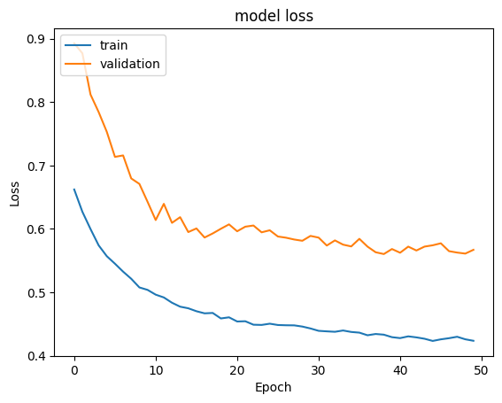

```python
# Compiling the model with 'cross entropy' as loss function, 'Adam' Optimizer and 'accuracy' metrics
model_07.compile(loss='binary_crossentropy',
              optimizer='SGD',
              metrics=['accuracy'])

# Fitting the model on train and validation with 50 epochs
fitted_model_07 = model_07.fit(X_train_over, y_train_over, validation_split=0.2,epochs=50)

#Plotting Train Loss vs Validation Loss
plt.plot(fitted_model_07.history['loss'])
plt.plot(fitted_model_07.history['val_loss'])
plt.title('model loss')
plt.ylabel('Loss')
plt.xlabel('Epoch')
plt.legend(['train', 'validation'], loc='upper left')
plt.show()
```

```python
# Obtain the y_predict from the X_test
y_pred=model_07.predict(X_test)

#set the threshold to 0.5
y_pred = (y_pred > 0.5)

# Display the classification report
cr=metrics.classification_report(y_test,y_pred)
print(cr)

#Calculating the confusion matrix
from sklearn.metrics import confusion_matrix
cm=confusion_matrix(y_test, y_pred)
labels = ['True Positive','False Negative','False Positive','True Negative']
categories = [ 'Not Exiting','Exiting']
make_confusion_matrix(cm,
                      group_names=labels,
                      categories=categories,
                      cmap='Blues')
```

[output not shown]

```python
from sklearn.metrics import roc_curve
from matplotlib import pyplot

# predict probabilities
yhat1 = model_07.predict(X_test)
# keep probabilities for the positive outcome only
yhat1 = yhat1[:, 0]
# calculate roc curves
fpr, tpr, thresholds1 = roc_curve(y_test, yhat1)

# plot the roc curve for the model
pyplot.plot([0,1], [0,1], linestyle='--')
pyplot.plot(fpr, tpr, marker='.')

# axis labels
pyplot.xlabel('False Positive Rate')
pyplot.ylabel('True Positive Rate')

# show the plot
pyplot.show()
```

[output not shown]

As we are searching for the threshold that will give us a good TPR value and still maintain. good FPR Value, we will aim for the threshold at TPR value close to 0.80

- Hidden layers = 4
- Activation function for hidden layers = Relu
- Weight initialization technique = non
- Output layer with 1 nodes
- Outout Activation function = Sigmoid
- Output loss function = Cross Entropy (since this is a classification problem)
- Optimizer = SGD
- epochs = 50
- Data is not scaled
- Regularization technique: Batch

```python
backend.clear_session()
#Fixing the seed for random number generators so that we can ensure we receive the same output everytime
np.random.seed(1)
random.seed(1)
tf.random.set_seed(1)
```

```
200/200 ━━━━━━━━━━━━━━━━━━━━ 2s 4ms/step - accuracy: 0.6515 - loss: 0.6997 - val_accuracy: 0.7887 - val_loss: 0.5335
200/200 ━━━━━━━━━━━━━━━━━━━━ 1s 2ms/step - accuracy: 0.7830 - loss: 0.5220 - val_accuracy: 0.7837 - val_loss: 0.5199
200/200 ━━━━━━━━━━━━━━━━━━━━ 1s 3ms/step - accuracy: 0.7921 - loss: 0.5059 - val_accuracy: 0.7900 - val_loss: 0.5145
200/200 ━━━━━━━━━━━━━━━━━━━━ 1s 2ms/step - accuracy: 0.7920 - loss: 0.5028 - val_accuracy: 0.7894 - val_loss: 0.5147
200/200 ━━━━━━━━━━━━━━━━━━━━ 1s 3ms/step - accuracy: 0.7927 - loss: 0.5014 - val_accuracy: 0.7887 - val_loss: 0.5191
200/200 ━━━━━━━━━━━━━━━━━━━━ 1s 3ms/step - accuracy: 0.7925 - loss: 0.5003 - val_accuracy: 0.7887 - val_loss: 0.5122
200/200 ━━━━━━━━━━━━━━━━━━━━ 1s 2ms/step - accuracy: 0.7923 - loss: 0.4993 - val_accuracy: 0.7887 - val_loss: 0.5104
200/200 ━━━━━━━━━━━━━━━━━━━━ 1s 3ms/step - accuracy: 0.7920 - loss: 0.4991 - val_accuracy: 0.7881 - val_loss: 0.5222
200/200 ━━━━━━━━━━━━━━━━━━━━ 1s 3ms/step - accuracy: 0.7922 - loss: 0.4986 - val_accuracy: 0.7887 - val_loss: 0.5173
200/200 ━━━━━━━━━━━━━━━━━━━━ 1s 3ms/step - accuracy: 0.7921 - loss: 0.4978 - val_accuracy: 0.7887 - val_loss: 0.5198
200/200 ━━━━━━━━━━━━━━━━━━━━ 1s 2ms/step - accuracy: 0.7920 - loss: 0.4970 - val_accuracy: 0.7894 - val_loss: 0.5199
200/200 ━━━━━━━━━━━━━━━━━━━━ 1s 2ms/step - accuracy: 0.7921 - loss: 0.4972 - val_accuracy: 0.7894 - val_loss: 0.5207
200/200 ━━━━━━━━━━━━━━━━━━━━ 1s 4ms/step - accuracy: 0.7918 - loss: 0.4961 - val_accuracy: 0.7894 - val_loss: 0.5244
200/200 ━━━━━━━━━━━━━━━━━━━━ 1s 4ms/step - accuracy: 0.7920 - loss: 0.4962 - val_accuracy: 0.7894 - val_loss: 0.5235
200/200 ━━━━━━━━━━━━━━━━━━━━ 1s 4ms/step - accuracy: 0.7917 - loss: 0.4956 - val_accuracy: 0.7894 - val_loss: 0.5234
200/200 ━━━━━━━━━━━━━━━━━━━━ 1s 3ms/step - accuracy: 0.7917 - loss: 0.4950 - val_accuracy: 0.7894 - val_loss: 0.5231
200/200 ━━━━━━━━━━━━━━━━━━━━ 1s 3ms/step - accuracy: 0.7915 - loss: 0.4950 - val_accuracy: 0.7894 - val_loss: 0.5209
200/200 ━━━━━━━━━━━━━━━━━━━━ 1s 3ms/step - accuracy: 0.7919 - loss: 0.4950 - val_accuracy: 0.7894 - val_loss: 0.5203
200/200 ━━━━━━━━━━━━━━━━━━━━ 1s 3ms/step - accuracy: 0.7921 - loss: 0.4943 - val_accuracy: 0.7894 - val_loss: 0.5179
200/200 ━━━━━━━━━━━━━━━━━━━━ 1s 3ms/step - accuracy: 0.7915 - loss: 0.4936 - val_accuracy: 0.7894 - val_loss: 0.5228
200/200 ━━━━━━━━━━━━━━━━━━━━ 1s 3ms/step - accuracy: 0.7919 - loss: 0.4928 - val_accuracy: 0.7894 - val_loss: 0.5234
200/200 ━━━━━━━━━━━━━━━━━━━━ 1s 3ms/step - accuracy: 0.7919 - loss: 0.4928 - val_accuracy: 0.7894 - val_loss: 0.5252
200/200 ━━━━━━━━━━━━━━━━━━━━ 1s 3ms/step - accuracy: 0.7924 - loss: 0.4927 - val_accuracy: 0.7894 - val_loss: 0.5258
200/200 ━━━━━━━━━━━━━━━━━━━━ 1s 3ms/step - accuracy: 0.7921 - loss: 0.4926 - val_accuracy: 0.7894 - val_loss: 0.5248
200/200 ━━━━━━━━━━━━━━━━━━━━ 1s 3ms/step - accuracy: 0.7917 - loss: 0.4923 - val_accuracy: 0.7894 - val_loss: 0.5249
200/200 ━━━━━━━━━━━━━━━━━━━━ 1s 3ms/step - accuracy: 0.7918 - loss: 0.4917 - val_accuracy: 0.7894 - val_loss: 0.5255
200/200 ━━━━━━━━━━━━━━━━━━━━ 1s 3ms/step - accuracy: 0.7915 - loss: 0.4917 - val_accuracy: 0.7894 - val_loss: 0.5304
200/200 ━━━━━━━━━━━━━━━━━━━━ 1s 3ms/step - accuracy: 0.7915 - loss: 0.4925 - val_accuracy: 0.7894 - val_loss: 0.5300
200/200 ━━━━━━━━━━━━━━━━━━━━ 1s 3ms/step - accuracy: 0.7910 - loss: 0.4918 - val_accuracy: 0.7894 - val_loss: 0.5297
200/200 ━━━━━━━━━━━━━━━━━━━━ 1s 2ms/step - accuracy: 0.7912 - loss: 0.4917 - val_accuracy: 0.7894 - val_loss: 0.5320
200/200 ━━━━━━━━━━━━━━━━━━━━ 1s 3ms/step - accuracy: 0.7910 - loss: 0.4908 - val_accuracy: 0.7894 - val_loss: 0.5334
200/200 ━━━━━━━━━━━━━━━━━━━━ 1s 4ms/step - accuracy: 0.7915 - loss: 0.4906 - val_accuracy: 0.7894 - val_loss: 0.5318
200/200 ━━━━━━━━━━━━━━━━━━━━ 1s 4ms/step - accuracy: 0.7926 - loss: 0.4901 - val_accuracy: 0.7894 - val_loss: 0.5313
200/200 ━━━━━━━━━━━━━━━━━━━━ 1s 4ms/step - accuracy: 0.7917 - loss: 0.4899 - val_accuracy: 0.7894 - val_loss: 0.5308
200/200 ━━━━━━━━━━━━━━━━━━━━ 1s 4ms/step - accuracy: 0.7914 - loss: 0.4904 - val_accuracy: 0.7894 - val_loss: 0.5339
200/200 ━━━━━━━━━━━━━━━━━━━━ 1s 2ms/step - accuracy: 0.7923 - loss: 0.4906 - val_accuracy: 0.7894 - val_loss: 0.5390
200/200 ━━━━━━━━━━━━━━━━━━━━ 1s 3ms/step - accuracy: 0.7921 - loss: 0.4900 - val_accuracy: 0.7894 - val_loss: 0.5399
200/200 ━━━━━━━━━━━━━━━━━━━━ 1s 3ms/step - accuracy: 0.7924 - loss: 0.4895 - val_accuracy: 0.7894 - val_loss: 0.5413
200/200 ━━━━━━━━━━━━━━━━━━━━ 1s 4ms/step - accuracy: 0.7918 - loss: 0.4888 - val_accuracy: 0.7894 - val_loss: 0.5405
200/200 ━━━━━━━━━━━━━━━━━━━━ 1s 4ms/step - accuracy: 0.7919 - loss: 0.4886 - val_accuracy: 0.7894 - val_loss: 0.5397
200/200 ━━━━━━━━━━━━━━━━━━━━ 1s 4ms/step - accuracy: 0.7915 - loss: 0.4882 - val_accuracy: 0.7894 - val_loss: 0.5383
200/200 ━━━━━━━━━━━━━━━━━━━━ 1s 4ms/step - accuracy: 0.7921 - loss: 0.4886 - val_accuracy: 0.7894 - val_loss: 0.5378
200/200 ━━━━━━━━━━━━━━━━━━━━ 1s 4ms/step - accuracy: 0.7923 - loss: 0.4876 - val_accuracy: 0.7894 - val_loss: 0.5399
200/200 ━━━━━━━━━━━━━━━━━━━━ 1s 4ms/step - accuracy: 0.7926 - loss: 0.4879 - val_accuracy: 0.7894 - val_loss: 0.5425
200/200 ━━━━━━━━━━━━━━━━━━━━ 2s 7ms/step - accuracy: 0.7921 - loss: 0.4882 - val_accuracy: 0.7894 - val_loss: 0.5401
200/200 ━━━━━━━━━━━━━━━━━━━━ 2s 4ms/step - accuracy: 0.7919 - loss: 0.4872 - val_accuracy: 0.7894 - val_loss: 0.5370
200/200 ━━━━━━━━━━━━━━━━━━━━ 1s 4ms/step - accuracy: 0.7916 - loss: 0.4868 - val_accuracy: 0.7894 - val_loss: 0.5396
200/200 ━━━━━━━━━━━━━━━━━━━━ 1s 2ms/step - accuracy: 0.7932 - loss: 0.4876 - val_accuracy: 0.7894 - val_loss: 0.5448
200/200 ━━━━━━━━━━━━━━━━━━━━ 1s 3ms/step - accuracy: 0.7928 - loss: 0.4868 - val_accuracy: 0.7894 - val_loss: 0.5484
200/200 ━━━━━━━━━━━━━━━━━━━━ 1s 3ms/step - accuracy: 0.7929 - loss: 0.4872 - val_accuracy: 0.7894 - val_loss: 0.5381
```

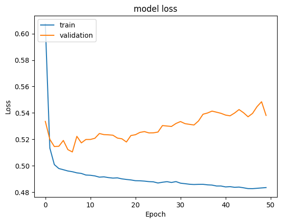

```python
# Initializing the model
model_08 = Sequential()
# Adding the first hidden layer with relu as activation function
model_08.add(Dense(160, activation='relu', input_dim=11))
# Adding Batch Normalization
model_08.add(BatchNormalization())
# Adding the second hidden layer with relu as activation function
model_08.add(Dense(64, activation='relu', input_dim=11))
# Adding Batch Normalization
model_08.add(BatchNormalization())
# Adding the third hidden layer with relu as activation function
model_08.add(Dense(32, activation='relu'))
# Adding Batch Normalization
model_08.add(BatchNormalization())
# Adding the fourth hidden layer with relu as activation function
model_08.add(Dense(16, activation='relu'))
# Adding Batch Normalization
model_08.add(BatchNormalization())
# Adding the output layer with one neuron and Sigmoid as activation
model_08.add(Dense(1, activation='sigmoid'))

# Compiling the model with 'cross entropy' as loss function, 'Adam' Optimizer and 'accuracy' metrics
model_08.compile(loss='binary_crossentropy',
              optimizer='SGD',
              metrics=['accuracy'])

# Fitting the model on train and validation with 20 epochs
fitted_model_08 = model_08.fit(X_train_ns, y_train_ns, validation_split=0.2,epochs=50)

#Plotting Train Loss vs Validation Loss
plt.plot(fitted_model_08.history['loss'])
plt.plot(fitted_model_08.history['val_loss'])
plt.title('model loss')
plt.ylabel('Loss')
plt.xlabel('Epoch')
plt.legend(['train', 'validation'], loc='upper left')
plt.show()
```

```python
# Obtain the y_predict from the X_test
y_pred=model_08.predict(X_test_ns)

#set the threshold to 0.5
y_pred = (y_pred > 0.5)

# Display the classification report
cr=metrics.classification_report(y_test_ns,y_pred)
print(cr)

#Calculating the confusion matrix
from sklearn.metrics import confusion_matrix
cm=confusion_matrix(y_test_ns, y_pred)
labels = ['True Positive','False Negative','False Positive','True Negative']
categories = [ 'Not Exiting','Exiting']
make_confusion_matrix(cm,
                      group_names=labels,
                      categories=categories,
                      cmap='Blues')
```

[output not shown]

- Hidden layers = 5
- Activation function for hidden layers = Relu
- Output layer with 1 nodes
- Output Activation function = Sigmoid
- Output loss function = Cross Entropy (since this is a classification problem)
- Optimizer = SGD
- epochs = 50
- Data is scaled using zscore
- Regularization technique: DropOut

```python
from sklearn.model_selection import GridSearchCV
```

```python
backend.clear_session()
#Fixing the seed for random number generators so that we can ensure we receive the same output everytime
np.random.seed(1)
random.seed(1)
tf.random.set_seed(1)
```

```python
def create_model(lr,batch_size):
    np.random.seed(1)
    model = Sequential()
    model.add(Dense(256,activation='relu',input_dim = 11))
    model.add(Dropout(0.2))
    model.add(Dense(128,activation='relu'))
    model.add(Dropout(0.2))
    model.add(Dense(65,activation='relu'))
    model.add(Dropout(0.2))
    model.add(Dense(32,activation='relu'))
    model.add(Dropout(0.2))
    model.add(Dense(16,activation='relu',kernel_initializer='he_uniform'))
    model.add(Dropout(0.3))
    model.add(Dense(1, activation='sigmoid'))

    #compile model
    optimizer = tf.keras.optimizers.SGD(learning_rate=lr)
    model.compile(optimizer = optimizer,loss = 'binary_crossentropy', metrics = ['accuracy'])
    return model
```

```python
!pip install scikeras
from scikeras.wrappers import KerasClassifier
#from tensorflow.keras.wrappers.scikit_learn import KerasClassifier


keras_estimator = KerasClassifier(build_fn=create_model, verbose=1)
# define the grid search parameters
param_grid = {
    'batch_size':[64,32, 128, 256, 560, 1000],
    "lr":[0.001,0.0015,0.0020,0.0025],}

kfold_splits = 3
grid = GridSearchCV(estimator=keras_estimator,
                    verbose=1,
                    cv=kfold_splits,
                    param_grid=param_grid,n_jobs=-1)
```

```python
from scikeras.wrappers import KerasClassifier
from sklearn.model_selection import GridSearchCV
import time

# Define model-building function
def create_model():
    from tensorflow.keras.models import Sequential
    from tensorflow.keras.layers import Dense
    model = Sequential()
    model.add(Dense(12, input_shape=(X_train.shape[1],), activation='relu'))
    model.add(Dense(1, activation='sigmoid'))
    model.compile(optimizer='adam', loss='binary_crossentropy', metrics=['accuracy'])
    return model

# Wrap the model with KerasClassifier
keras_estimator = KerasClassifier(model=create_model, verbose=1)  # Set verbose here

# Define grid parameters (ensure these are accepted by KerasClassifier)
param_grid = {
    'batch_size': [10, 20, 40],
    'epochs': [10, 20]
}

# Set up GridSearchCV with KerasClassifier and parameters
grid = GridSearchCV(estimator=keras_estimator, param_grid=param_grid, n_jobs=-1, cv=3, verbose=1)

# Store starting time
begin = time.time()

# Fit without validation_split and verbose in the fit() call
grid_result = grid.fit(X_train, y_train)

# Summarize results
print("Best: %f using %s" % (grid_result.best_score_, grid_result.best_params_))
means = grid_result.cv_results_['mean_test_score']
stds = grid_result.cv_results_['std_test_score']
params = grid_result.cv_results_['params']

# Store end time
end = time.time()

# Total time taken
print(f"Total runtime of the program is {end - begin}")
```

```
Fitting 3 folds for each of 6 candidates, totalling 18 fits
400/400 ━━━━━━━━━━━━━━━━━━━━ 1s 1ms/step - accuracy: 0.6487 - loss: 0.6364
400/400 ━━━━━━━━━━━━━━━━━━━━ 1s 1ms/step - accuracy: 0.8147 - loss: 0.4386
400/400 ━━━━━━━━━━━━━━━━━━━━ 1s 1ms/step - accuracy: 0.8231 - loss: 0.4153
400/400 ━━━━━━━━━━━━━━━━━━━━ 1s 1ms/step - accuracy: 0.8336 - loss: 0.4008
400/400 ━━━━━━━━━━━━━━━━━━━━ 1s 2ms/step - accuracy: 0.8441 - loss: 0.3875
400/400 ━━━━━━━━━━━━━━━━━━━━ 1s 1ms/step - accuracy: 0.8500 - loss: 0.3759
400/400 ━━━━━━━━━━━━━━━━━━━━ 1s 1ms/step - accuracy: 0.8553 - loss: 0.3665
400/400 ━━━━━━━━━━━━━━━━━━━━ 1s 1ms/step - accuracy: 0.8562 - loss: 0.3590
400/400 ━━━━━━━━━━━━━━━━━━━━ 1s 1ms/step - accuracy: 0.8588 - loss: 0.3533
400/400 ━━━━━━━━━━━━━━━━━━━━ 1s 1ms/step - accuracy: 0.8592 - loss: 0.3491
400/400 ━━━━━━━━━━━━━━━━━━━━ 1s 2ms/step - accuracy: 0.8589 - loss: 0.3461
400/400 ━━━━━━━━━━━━━━━━━━━━ 1s 2ms/step - accuracy: 0.8600 - loss: 0.3439
400/400 ━━━━━━━━━━━━━━━━━━━━ 1s 2ms/step - accuracy: 0.8607 - loss: 0.3421
400/400 ━━━━━━━━━━━━━━━━━━━━ 1s 2ms/step - accuracy: 0.8611 - loss: 0.3409
400/400 ━━━━━━━━━━━━━━━━━━━━ 1s 2ms/step - accuracy: 0.8613 - loss: 0.3399
400/400 ━━━━━━━━━━━━━━━━━━━━ 1s 2ms/step - accuracy: 0.8618 - loss: 0.3391
400/400 ━━━━━━━━━━━━━━━━━━━━ 1s 2ms/step - accuracy: 0.8619 - loss: 0.3384
400/400 ━━━━━━━━━━━━━━━━━━━━ 1s 1ms/step - accuracy: 0.8618 - loss: 0.3379
400/400 ━━━━━━━━━━━━━━━━━━━━ 1s 2ms/step - accuracy: 0.8621 - loss: 0.3374
400/400 ━━━━━━━━━━━━━━━━━━━━ 1s 2ms/step - accuracy: 0.8617 - loss: 0.3371
Best: 0.857500 using {'batch_size': 20, 'epochs': 20}
Total runtime of the program is 216.47132635116577
```

```python
from tensorflow.keras.models import Sequential
from tensorflow.keras.layers import Dense
from tensorflow.keras.optimizers import Adam

# Define the model creation function to accept batch_size and lr
def create_model(batch_size=None, lr=0.001):
    model = Sequential()
    model.add(Dense(12, input_shape=(X_train.shape[1],), activation='relu'))
    model.add(Dense(1, activation='sigmoid'))

    # Compile the model with the specified learning rate
    optimizer = Adam(learning_rate=lr)
    model.compile(optimizer=optimizer, loss='binary_crossentropy', metrics=['accuracy'])
    return model
# Extract the best parameters and create the model with those parameters
best_batch_size = grid_result.best_params_.get('batch_size', 32)  # Provide default in case it's missing
best_lr = grid_result.best_params_.get('lr', 0.001)

# Instantiate the model with optimal parameters
model_09 = create_model(batch_size=best_batch_size, lr=best_lr)

# Display the model structure
model_09.summary()
```

```
Model: "sequential_1"
```

```
┏━━━━━━━━━━━━━━━━━━━━━━━━━━━━━━━━━━━━━━┳━━━━━━━━━━━━━━━━━━━━━━━━━━━━━┳━━━━━━━━━━━━━━━━━┓
┃ Layer (type)                         ┃ Output Shape                ┃         Param # ┃
┡━━━━━━━━━━━━━━━━━━━━━━━━━━━━━━━━━━━━━━╇━━━━━━━━━━━━━━━━━━━━━━━━━━━━━╇━━━━━━━━━━━━━━━━━┩
│ dense_2 (Dense)                      │ (None, 12)                  │             144 │
├──────────────────────────────────────┼─────────────────────────────┼─────────────────┤
│ dense_3 (Dense)                      │ (None, 1)                   │              13 │
└──────────────────────────────────────┴─────────────────────────────┴─────────────────┘
```

```
 Total params: 157 (628.00 B)
```

```
 Trainable params: 157 (628.00 B)
```

```
 Non-trainable params: 0 (0.00 B)
```

```python
# Get the best parameters, providing a default value for lr if not found
best_batch_size = grid_result.best_params_.get('batch_size', 32)
best_lr = grid_result.best_params_.get('lr', 0.001)  # Default to 0.001 if 'lr' is missing

# Prepare the optimizer with the best learning rate
from tensorflow.keras.optimizers import SGD
optimizer = SGD(learning_rate=best_lr)

# Compile and build the model with the best parameters
model_09 = create_model(batch_size=best_batch_size, lr=best_lr)
model_09.compile(loss='binary_crossentropy', optimizer=optimizer, metrics=['accuracy'])

# Display the model structure
model_09.summary()
```

```
Model: "sequential_2"
```

```
┏━━━━━━━━━━━━━━━━━━━━━━━━━━━━━━━━━━━━━━┳━━━━━━━━━━━━━━━━━━━━━━━━━━━━━┳━━━━━━━━━━━━━━━━━┓
┃ Layer (type)                         ┃ Output Shape                ┃         Param # ┃
┡━━━━━━━━━━━━━━━━━━━━━━━━━━━━━━━━━━━━━━╇━━━━━━━━━━━━━━━━━━━━━━━━━━━━━╇━━━━━━━━━━━━━━━━━┩
│ dense_4 (Dense)                      │ (None, 12)                  │             144 │
├──────────────────────────────────────┼─────────────────────────────┼─────────────────┤
│ dense_5 (Dense)                      │ (None, 1)                   │              13 │
└──────────────────────────────────────┴─────────────────────────────┴─────────────────┘
```

```
 Total params: 157 (628.00 B)
```

```
 Trainable params: 157 (628.00 B)
```

```
 Non-trainable params: 0 (0.00 B)
```

```
256/256 ━━━━━━━━━━━━━━━━━━━━ 2s 4ms/step - accuracy: 0.4195 - loss: 0.9554 - val_accuracy: 0.4812 - val_loss: 0.8336
256/256 ━━━━━━━━━━━━━━━━━━━━ 1s 3ms/step - accuracy: 0.5261 - loss: 0.7951 - val_accuracy: 0.5727 - val_loss: 0.7212
256/256 ━━━━━━━━━━━━━━━━━━━━ 1s 3ms/step - accuracy: 0.5979 - loss: 0.6924 - val_accuracy: 0.6281 - val_loss: 0.6494
256/256 ━━━━━━━━━━━━━━━━━━━━ 1s 2ms/step - accuracy: 0.6545 - loss: 0.6268 - val_accuracy: 0.6758 - val_loss: 0.6030
256/256 ━━━━━━━━━━━━━━━━━━━━ 1s 2ms/step - accuracy: 0.7073 - loss: 0.5843 - val_accuracy: 0.7125 - val_loss: 0.5722
256/256 ━━━━━━━━━━━━━━━━━━━━ 1s 2ms/step - accuracy: 0.7355 - loss: 0.5559 - val_accuracy: 0.7461 - val_loss: 0.5511
256/256 ━━━━━━━━━━━━━━━━━━━━ 1s 3ms/step - accuracy: 0.7593 - loss: 0.5364 - val_accuracy: 0.7633 - val_loss: 0.5361
256/256 ━━━━━━━━━━━━━━━━━━━━ 1s 3ms/step - accuracy: 0.7753 - loss: 0.5225 - val_accuracy: 0.7695 - val_loss: 0.5251
256/256 ━━━━━━━━━━━━━━━━━━━━ 1s 3ms/step - accuracy: 0.7859 - loss: 0.5121 - val_accuracy: 0.7773 - val_loss: 0.5167
256/256 ━━━━━━━━━━━━━━━━━━━━ 1s 3ms/step - accuracy: 0.7917 - loss: 0.5040 - val_accuracy: 0.7766 - val_loss: 0.5101
256/256 ━━━━━━━━━━━━━━━━━━━━ 1s 2ms/step - accuracy: 0.7922 - loss: 0.4976 - val_accuracy: 0.7828 - val_loss: 0.5048
256/256 ━━━━━━━━━━━━━━━━━━━━ 1s 2ms/step - accuracy: 0.7933 - loss: 0.4923 - val_accuracy: 0.7844 - val_loss: 0.5003
256/256 ━━━━━━━━━━━━━━━━━━━━ 1s 2ms/step - accuracy: 0.7944 - loss: 0.4878 - val_accuracy: 0.7852 - val_loss: 0.4965
256/256 ━━━━━━━━━━━━━━━━━━━━ 1s 2ms/step - accuracy: 0.7954 - loss: 0.4839 - val_accuracy: 0.7867 - val_loss: 0.4933
256/256 ━━━━━━━━━━━━━━━━━━━━ 1s 2ms/step - accuracy: 0.7962 - loss: 0.4804 - val_accuracy: 0.7867 - val_loss: 0.4904
256/256 ━━━━━━━━━━━━━━━━━━━━ 1s 2ms/step - accuracy: 0.7964 - loss: 0.4773 - val_accuracy: 0.7875 - val_loss: 0.4878
256/256 ━━━━━━━━━━━━━━━━━━━━ 0s 2ms/step - accuracy: 0.7966 - loss: 0.4745 - val_accuracy: 0.7867 - val_loss: 0.4855
256/256 ━━━━━━━━━━━━━━━━━━━━ 1s 2ms/step - accuracy: 0.7973 - loss: 0.4720 - val_accuracy: 0.7891 - val_loss: 0.4833
256/256 ━━━━━━━━━━━━━━━━━━━━ 0s 2ms/step - accuracy: 0.7972 - loss: 0.4696 - val_accuracy: 0.7891 - val_loss: 0.4814
256/256 ━━━━━━━━━━━━━━━━━━━━ 1s 2ms/step - accuracy: 0.7976 - loss: 0.4674 - val_accuracy: 0.7898 - val_loss: 0.4796
```

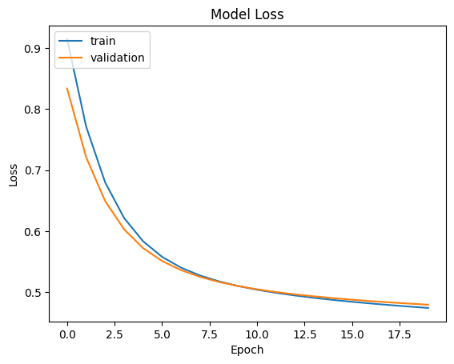

```python
# Define the parameter grid including 'epochs'
param_grid = {
    'batch_size': [10, 20, 40],
    'epochs': [10, 20, 30],  # Add different values for epochs
    'lr': [0.001, 0.01, 0.1]  # Assuming lr is also a parameter you tuned
}
# Retrieve the best parameters with default values
best_batch_size = grid_result.best_params_.get('batch_size', 32)
best_epochs = grid_result.best_params_.get('epochs', 10)  # Default to 10 epochs if missing
best_lr = grid_result.best_params_.get('lr', 0.001)

# Fit the model with validation split and capture history
history = model_09.fit(X_train, y_train, validation_split=0.2, epochs=best_epochs, batch_size=best_batch_size, verbose=1)

# Plotting Train Loss vs Validation Loss
import matplotlib.pyplot as plt

plt.plot(history.history['loss'], label='train')
plt.plot(history.history['val_loss'], label='validation')
plt.title('Model Loss')
plt.ylabel('Loss')
plt.xlabel('Epoch')
plt.legend(loc='upper left')
plt.show()
```

The validation loss curve is much smoother and the overfit is less. Also the average loss value that the curves converge to is within a lower range than observed in the previous model.

```
63/63 ━━━━━━━━━━━━━━━━━━━━ 0s 2ms/step
              precision    recall  f1-score   support

           0       0.80      0.99      0.88      1593
           1       0.40      0.02      0.04       407

    accuracy                           0.79      2000
   macro avg       0.60      0.51      0.46      2000
weighted avg       0.72      0.79      0.71      2000
```

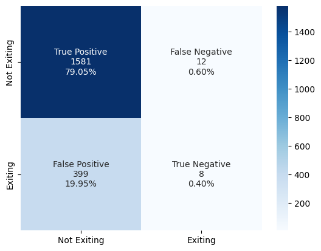

```python
# Obtain the y_predict from the X_test
y_pred=model_09.predict(X_test)

#set the threshold to 0.5
y_pred = (y_pred > 0.5)

# Display the classification report
cr=metrics.classification_report(y_test,y_pred)
print(cr)

#Calculating the confusion matrix
from sklearn.metrics import confusion_matrix
cm=confusion_matrix(y_test, y_pred)
labels = ['True Positive','False Negative','False Positive','True Negative']
categories = [ 'Not Exiting','Exiting']
make_confusion_matrix(cm,
                      group_names=labels,
                      categories=categories,
                      cmap='Blues')
```

Note: The GridSearchCV was trialed with the over sampled training set and the overfit was too high, hence the model was not included in this notebook.

**Model_10**  
In this model we will use the Keras Tuner to guide us through the best combination of :

- No. of layers
- No. of neurons per layer
- Learning rate